# 多维异常检测算法仿真（算法研究）

## 什么是异常检测？

也可称为过程监控，其主要目标是根据生产系统的运行状况，检测已经发生的故障或者实时地预测可能发生的故障，发出警报并指示发生故障的位置，以便生产维护人员的检查和维修，从而保证生产安全和产品质量，减少系统停机检修的次数。

## 异常检测的方法论

- 基于知识  
  方法：专家系统（能够根据现有数据，推理故障发生与否并决策是否报警以及如何修复） 问题：受知识的广度和深度制约，容易出现推理结果冲突、推理组合爆炸等问题
- 基于模型  
  方法：数学建模（为系统建立较为精确的数学模型，通过评估实际输出和预测输出的残差，判断系统是否处于正常运行状态）  
  问题：受系统复杂度制约，建模难度较高
- 基于数据  
  方法：通过记录系统运行的过程数据，采用合理的方法进行统筹和利用，达到对系统监控的目的 优势：简单，自学习能力强，不需要过多的先验知识

## 为什么需要多维异常检测？

系统生产运行过程中会存在着大量的、 高度相关的过程变量, 如温度、 压力、 流量、 液位等。这些过程变量处于一定的波动范围，对于监控生产过程的正常运行、 保证产品质量的一致性、 可靠性来说往往是至关重要的。 而由于单一监测指标本身受精度和灵敏度限制，在生产现场扰动较多的情况下，极易出现无故障虚假报警或者有故障不报的漏警现象，因此需要同时对各个变量进行监测，另一方面，由于多个变量间往往存在耦合和冗余，对于操作维护人员来说, 同时对大量的过程变量进行监控和识别又会显得效率十分低下，因此我们需要引入行之有效的多维异常检测技术来辅助人们改进系统监控的精准性和效率。

## 基于数据的多维异常检测技术

算法主要包括：主元分析法（PCA）、独立元分析法（ICA）、偏最小二乘法（PLS）、规范变量分析（CVA）、线性判别分析（LDA）等。通过一系列数学变换，用一个低维空间表示原始数据的主要特征，同时还会得到表征原始数据空间到低维特征空间映射关系的投影矩阵。在特征空间中构造统计量，并基于各种数学分布估计得到正常数据统计量的波动范围，这个范围我们称之为控制限。当新样本到达后，通过投影矩阵将新样本投影到特征空间，通过计算并判断其统计量的值是否超过控制限，就可以判断该新样本是否是正常样本。

## 1、数据采集

> 读取 CPU\磁盘读\磁盘写\网络出口\网络入口\内存等监控指标，数据来源：广西科大数据（2016.10-2016.11）

```python
import numpy as np
import pandas as pd
from pandas import Series,DataFrame
import matplotlib.pyplot as plt
%matplotlib inline
plt.rc('figure', figsize=(15, 6))
from dateutil.parser import parse
```

```python
vCpuUsage = pd.read_excel('../ECUST data/Guangxi university data 20161111/CPU_20161111105339.xlsx',converters={u'时间':parse})
vDiskRead = pd.read_excel('../ECUST data/Guangxi university data 20161111/DiskRead_20161111110123.xlsx',converters={u'时间':parse})
vDiskWrite = pd.read_excel('../ECUST data/Guangxi university data 20161111/DiskWrite_20161111110158.xlsx',converters={u'时间':parse})
vNwEgress = pd.read_excel('../ECUST data/Guangxi university data 20161111/NetworkEgress_20161111110304.xlsx',converters={u'时间':parse})
vNwIngress = pd.read_excel('../ECUST data/Guangxi university data 20161111/NetworkIngress_20161111110416.xlsx',converters={u'时间':parse})
vMemUsage = pd.read_excel('../ECUST data/Guangxi university data 20161111/Memory_20161111105932.xlsx',converters={u'时间':parse})
```

## 2.数据预处理

### 2.1、修改index和columns

```python
for var in (vCpuUsage,vDiskRead,vDiskWrite,vNwEgress,vNwIngress,vMemUsage):
    var.rename(columns={u'资源':'vres',u'类型':'vtype',u'时间':'vtime',u'最大值':'vmax',u'最小值':'vmin',u'平均值':'vavg',u'单位':'vunit'},
               inplace = True)
    if 'vtime' in var.columns.values:
        var.set_index('vtime',inplace=True)
```

### 2.2、初步探索时间序列数据,形成待分析多维数据矩阵X

```python
for var in (vCpuUsage,vDiskRead,vDiskWrite,vNwEgress,vNwIngress,vMemUsage):
    print(var.head())
    print('length :',len(var))
```

```
                           vres      vtype   vmax   vmin   vavg vunit
vtime
2016-10-01 00:00:09  JWC_WEB_ON  虚拟机CPU使用率  18.75  18.75  18.75     %
2016-10-01 00:01:08  JWC_WEB_ON  虚拟机CPU使用率   0.00   0.00   0.00     %
2016-10-01 00:02:09  JWC_WEB_ON  虚拟机CPU使用率   3.25   3.25   3.25     %
2016-10-01 00:03:09  JWC_WEB_ON  虚拟机CPU使用率   6.78   6.78   6.78     %
2016-10-01 00:04:08  JWC_WEB_ON  虚拟机CPU使用率   7.34   7.34   7.34     %
length : 59508
                           vres      vtype  vmax  vmin  vavg vunit
vtime
2016-10-01 00:09:48  JWC_WEB_ON  虚拟机磁盘读取速率   0.0   0.0   0.0   B/s
2016-10-01 00:19:49  JWC_WEB_ON  虚拟机磁盘读取速率   0.0   0.0   0.0   B/s
2016-10-01 00:29:49  JWC_WEB_ON  虚拟机磁盘读取速率   0.0   0.0   0.0   B/s
2016-10-01 00:39:51  JWC_WEB_ON  虚拟机磁盘读取速率   0.0   0.0   0.0   B/s
2016-10-01 00:49:50  JWC_WEB_ON  虚拟机磁盘读取速率   0.0   0.0   0.0   B/s
length : 6858
                           vres      vtype     vmax     vmin      vavg vunit
vtime
2016-10-01 00:09:49  JWC_WEB_ON  虚拟机磁盘写入速率  21977.6  21977.6  21977.60   B/s
2016-10-01 00:19:49  JWC_WEB_ON  虚拟机磁盘写入速率  22737.1  22737.1  22737.07   B/s
2016-10-01 00:29:50  JWC_WEB_ON  虚拟机磁盘写入速率  21402.6  21402.6  21402.62   B/s
2016-10-01 00:39:51  JWC_WEB_ON  虚拟机磁盘写入速率  26434.0  26434.0  26434.02   B/s
2016-10-01 00:49:51  JWC_WEB_ON  虚拟机磁盘写入速率  21766.0  21766.0  21765.97   B/s
length : 6859
                                             vres      vtype      vmax  \
vtime
2016-10-01 00:09:49  JWC_WEB_ON fa:16:3e:7e:ba:21  虚拟机网络出口带宽   5100.60
2016-10-01 00:19:50  JWC_WEB_ON fa:16:3e:7e:ba:21  虚拟机网络出口带宽   3735.84
2016-10-01 00:29:50  JWC_WEB_ON fa:16:3e:7e:ba:21  虚拟机网络出口带宽   2737.18
2016-10-01 00:39:51  JWC_WEB_ON fa:16:3e:7e:ba:21  虚拟机网络出口带宽  11229.00
2016-10-01 00:49:51  JWC_WEB_ON fa:16:3e:7e:ba:21  虚拟机网络出口带宽   3379.96

                         vmin      vavg vunit
vtime
2016-10-01 00:09:49   5100.60   5100.60   B/s
2016-10-01 00:19:50   3735.84   3735.84   B/s
2016-10-01 00:29:50   2737.18   2737.18   B/s
2016-10-01 00:39:51  11229.00  11228.95   B/s
2016-10-01 00:49:51   3379.96   3379.96   B/s
length : 6857
```

[output cut: 9 more lines]

```
vtime
2016-10-01 00:09:35  2406.23  2406.23   B/s
2016-10-01 00:19:36  1964.51  1964.51   B/s
2016-10-01 00:29:35  1851.89  1851.89   B/s
2016-10-01 00:39:37  9528.73  9528.73   B/s
2016-10-01 00:49:37  1106.68  1106.68   B/s
length : 6728
                           vres      vtype    vmax    vmin    vavg vunit
vtime
2016-10-01 00:00:08  JWC_WEB_ON  虚拟机内存使用情况  3351.0  3351.0  3351.0    MB
2016-10-01 00:01:08  JWC_WEB_ON  虚拟机内存使用情况  3342.0  3342.0  3342.0    MB
2016-10-01 00:02:08  JWC_WEB_ON  虚拟机内存使用情况  3342.0  3342.0  3342.0    MB
2016-10-01 00:03:08  JWC_WEB_ON  虚拟机内存使用情况  3340.0  3340.0  3340.0    MB
2016-10-01 00:04:08  JWC_WEB_ON  虚拟机内存使用情况  3347.0  3347.0  3347.0    MB
length : 59451
```

```python
vDiskRead.to_period('Min').head()
```

| vtime | vres | vtype | vmax | vmin | vavg | vunit |
| --- | --- | --- | --- | --- | --- | --- |
| 2016-10-01 00:09 | JWC_WEB_ON | 虚拟机磁盘读取速率 | 0.0 | 0.0 | 0.0 | B/s |
| 2016-10-01 00:19 | JWC_WEB_ON | 虚拟机磁盘读取速率 | 0.0 | 0.0 | 0.0 | B/s |
| 2016-10-01 00:29 | JWC_WEB_ON | 虚拟机磁盘读取速率 | 0.0 | 0.0 | 0.0 | B/s |
| 2016-10-01 00:39 | JWC_WEB_ON | 虚拟机磁盘读取速率 | 0.0 | 0.0 | 0.0 | B/s |
| 2016-10-01 00:49 | JWC_WEB_ON | 虚拟机磁盘读取速率 | 0.0 | 0.0 | 0.0 | B/s |

```python
X = pd.concat([vCpuUsage.to_period('Min').vavg,
               vDiskRead.to_period('Min').vavg,
               vDiskWrite.to_period('Min').vavg,
               vNwEgress.to_period('Min').vavg,
               vNwIngress.to_period('Min').vavg,
               vMemUsage.to_period('Min').vavg],axis=1,keys=['vCpuUsage','vDiskRead','vDiskWrite','vNwEgress','vNwIngress','vMemUsage'])
X.head()
```

| vtime | vCpuUsage | vDiskRead | vDiskWrite | vNwEgress | vNwIngress | vMemUsage |
| --- | --- | --- | --- | --- | --- | --- |
| 2016-10-01 00:00 | 18.75 | NaN | NaN | NaN | NaN | 3351.0 |
| 2016-10-01 00:01 | 0.00 | NaN | NaN | NaN | NaN | 3342.0 |
| 2016-10-01 00:02 | 3.25 | NaN | NaN | NaN | NaN | 3342.0 |
| 2016-10-01 00:03 | 6.78 | NaN | NaN | NaN | NaN | 3340.0 |
| 2016-10-01 00:04 | 7.34 | NaN | NaN | NaN | NaN | 3347.0 |

### 2.3、对缺失数据进行插值处理

> 缺失数据主要是由于各维度采集粒度差异引起的，可采取线性插值方法处理

```python
#设定初始值后，对NaN进行线性插值
X.ix[0,X.ix[0].isnull()]=0
X.interpolate(method='time',inplace=True)
X.head()
```

| vtime | vCpuUsage | vDiskRead | vDiskWrite | vNwEgress | vNwIngress | vMemUsage |
| --- | --- | --- | --- | --- | --- | --- |
| 2016-10-01 00:00 | 18.75 | 0.0 | 0.000000 | 0.000000 | 0.000000 | 3351.0 |
| 2016-10-01 00:01 | 0.00 | 0.0 | 2441.955556 | 566.733333 | 267.358889 | 3342.0 |
| 2016-10-01 00:02 | 3.25 | 0.0 | 4883.911111 | 1133.466667 | 534.717778 | 3342.0 |
| 2016-10-01 00:03 | 6.78 | 0.0 | 7325.866667 | 1700.200000 | 802.076667 | 3340.0 |
| 2016-10-01 00:04 | 7.34 | 0.0 | 9767.822222 | 2266.933333 | 1069.435556 | 3347.0 |

### 2.4、对CPU 0值数据进行填充

> 系统运行过程中，CPU出现0值是不正常的，可能原因是CPU过高导致无法正常上报指标，因此取0值前的有效值进行填充

```python
for i in range(1,len(X.vCpuUsage)):
    if X.vCpuUsage[i]==0:
        X.vCpuUsage[i] = X.vCpuUsage[i-1]
```

```python
X_mean=X.mean()
X_std=X.std()
#保留原始值
X_Original=X
X.describe()
```

|  | vCpuUsage | vDiskRead | vDiskWrite | vNwEgress | vNwIngress | vMemUsage |
| --- | --- | --- | --- | --- | --- | --- |
| count | 59659.000000 | 5.965900e+04 | 59659.000000 | 59659.000000 | 59659.000000 | 59659.000000 |
| mean | 26.807820 | 1.497316e+03 | 24419.527161 | 7267.443309 | 4593.172306 | 3040.001054 |
| std | 26.244971 | 3.936387e+04 | 13922.662687 | 10317.993604 | 8243.010618 | 435.512551 |
| min | 0.040000 | 0.000000e+00 | 0.000000 | 0.000000 | 0.000000 | 821.000000 |
| 25% | 7.590000 | 0.000000e+00 | 19837.838000 | 612.369000 | 411.638500 | 2849.000000 |
| 50% | 14.550000 | 0.000000e+00 | 22264.405000 | 4209.350000 | 2054.915000 | 3084.000000 |
| 75% | 38.825000 | 0.000000e+00 | 25588.961500 | 9666.147500 | 5363.120000 | 3362.000000 |
| max | 100.000000 | 3.519854e+06 | 541131.000000 | 147526.730000 | 233198.560000 | 3897.000000 |

### 2.5、标准化

```python
from sklearn import preprocessing
from sklearn.preprocessing import StandardScaler
```

```python
X_scaler=StandardScaler().fit(X)
#scikit learn操作的数据类型为ndarray，因此再次转换为DataFrame
X = DataFrame(X_scaler.transform(X),index=X.index,columns=X.columns)
X_mean=X.mean()
X_std=X.std()
print('std var:\n',X_std,'\n\n','mean:\n',X_mean)
```

```
std var:
 vCpuUsage     1.000008
vDiskRead     1.000008
vDiskWrite    1.000008
vNwEgress     1.000008
vNwIngress    1.000008
vMemUsage     1.000008
dtype: float64

 mean:
 vCpuUsage     5.897158e-16
vDiskRead     5.159902e-15
vDiskWrite    5.206849e-16
vNwEgress    -1.372282e-16
vNwIngress    4.822089e-16
vMemUsage    -2.082012e-15
dtype: float64
```

### 2.6、多维数据图形化探索

```
array([[<matplotlib.axes._subplots.AxesSubplot object at 0x7f0f3bc80b00>,
        <matplotlib.axes._subplots.AxesSubplot object at 0x7f0f3a2185f8>]], dtype=object)
```

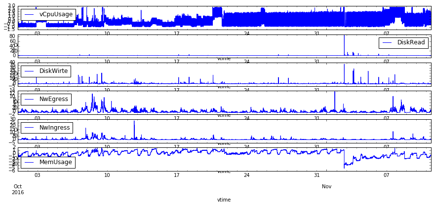

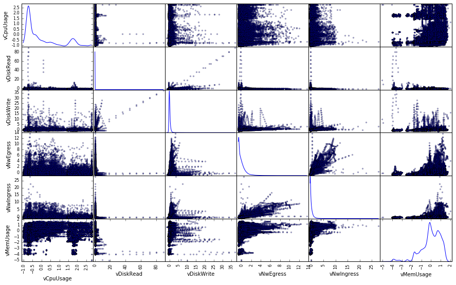

```python
plt.subplot(611)
X.vCpuUsage.plot(label='vCpuUsage')
plt.legend(loc='best')
plt.subplot(612)
X.vDiskRead.plot(label='DiskRead')
plt.legend(loc='best')
plt.subplot(613)
X.vDiskWrite.plot(label='DiskWirte')
plt.legend(loc='best')
plt.subplot(614)
X.vNwEgress.plot(label='NwEgress')
plt.legend(loc='best')
plt.subplot(615)
X.vNwIngress.plot(label='NwIngress')
plt.legend(loc='best')
plt.subplot(616)
X.vMemUsage.plot(label='MemUsage')
plt.legend(loc='best')

pd.scatter_matrix(X,diagonal='kde',color='k',alpha=0.3,figsize=(15,9))
```

> 直观感觉：1）特征之间有线性相关性；2）特征的高斯性不明显；3）Nw I/O在已知的故障时刻变化不明显

## 3、算法比较

```python
# 保留 <百分比 components_percent> 的主成分
components_percent=0.85
```

### 3.1、PCA

```python
from sklearn.decomposition import PCA
import numpy.linalg as nlg
```

#### 3.1.1、PCA数据探索

```python
X_pca=PCA().fit(X)
```

```python
print('covariance matrix is:\n',X_pca.get_covariance())
print('\nexplained_variance is: \n',X_pca.explained_variance_)
print('\nexplained_variance ratio is: \n',X_pca.explained_variance_ratio_)
```

```
covariance matrix is:
 [[ 1.         -0.00235122  0.02971026  0.07676271  0.01774433  0.04023799]
 [-0.00235122  1.          0.48996776 -0.01052607 -0.01240796 -0.09590145]
 [ 0.02971026  0.48996776  1.          0.27951496  0.26356957  0.13671553]
 [ 0.07676271 -0.01052607  0.27951496  1.          0.83419459  0.31194841]
 [ 0.01774433 -0.01240796  0.26356957  0.83419459  1.          0.27734822]
 [ 0.04023799 -0.09590145  0.13671553  0.31194841  0.27734822  1.        ]]

explained_variance is:
 [ 2.17006501  1.41204873  0.99703689  0.82181019  0.43618313  0.16285605]

explained_variance ratio is:
 [ 0.3616775   0.23534145  0.16617281  0.13696836  0.07269719  0.02714267]
```

> - NwEgress,NwIngress有较强的线性相关性(0.83419459)，DiskRead,DiskWrite的相关性也不低（0.48996776），另外，MemUsage与Nw I/O也都有一定的相关性（0.31194841，0.27734822），为避免各个特征的相互干扰，应通过PCA去除这种线性相关
> - 通过PCA进行特征转换后，某些分量对应的特征值远小于其他值，说明该分量对于样本区分几乎无贡献，出于降维考虑可丢弃

```python
#指定主成分的方差和所占的最小比例阈值为components_percent
X_pca=PCA(n_components=components_percent).fit(X)
print(X_pca.components_)
```

```
[[ 0.06991308  0.1150879   0.37004199  0.60922343  0.59823566  0.34043615]
 [ 0.0269821  -0.7442306  -0.57062969  0.176527    0.17702978  0.23931822]
 [-0.99300565 -0.00733066 -0.00805875  0.0347123   0.10683182 -0.03468586]
 [ 0.07632765 -0.02850398 -0.14985011  0.27385976  0.31774324 -0.89159779]]
```

```python
print(X.ix[0].shape,X_pca.components_.shape,X_pca.explained_variance_.shape,len(X))
```

```
(6,) (4, 6) (4,) 59659
```

```python
X_pca_recover=DataFrame(np.dot(X,np.dot(X_pca.components_.T,X_pca.components_)),index=X.index,columns=X.columns)
```

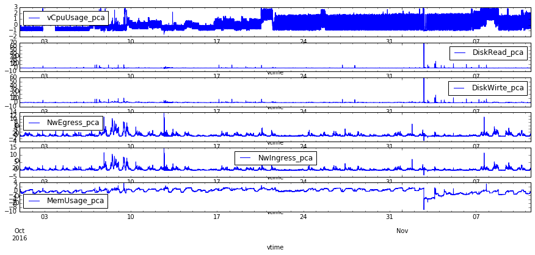

```python
plt.subplot(611)
X_pca_recover.vCpuUsage.plot(label='vCpuUsage_pca')
plt.legend(loc='best')
plt.subplot(612)
X_pca_recover.vDiskRead.plot(label='DiskRead_pca')
plt.legend(loc='best')
plt.subplot(613)
X_pca_recover.vDiskWrite.plot(label='DiskWirte_pca')
plt.legend(loc='best')
plt.subplot(614)
X_pca_recover.vNwEgress.plot(label='NwEgress_pca')
plt.legend(loc='best')
plt.subplot(615)
X_pca_recover.vNwIngress.plot(label='NwIngress_pca')
plt.legend(loc='best')
plt.subplot(616)
X_pca_recover.vMemUsage.plot(label='MemUsage_pca')
plt.legend(loc='best')
```

```python
from sklearn.metrics import r2_score
```

```python
r2_score(X,X_pca_recover,multioutput='variance_weighted')
```

```
0.90016013660614036
```

> 通过PCA降维，只保留4个维度的数据，也能较好的恢复原数据

```python
#计算T2统计量
X_pca_T2=Series([np.dot(np.dot(np.dot(np.dot(X.ix[i].T,X_pca.components_.T),nlg.inv(np.diag(X_pca.explained_variance_))),X_pca.components_),X.ix[i]) for i in np.arange(len(X))],
         index=X.index)
```

```python
#计算SPE统计量
X_pca_SPE=Series(np.sum((X-X_pca_recover)**2,axis=1),index=X.index)
```

#### 3.1.2、采用置信度确定阈值

##### option1:使用scikit learn 的KDE API估计概率密度

```python
from sklearn.neighbors import KernelDensity
```

```python
X_pca_T2_scikit_kde=KernelDensity().fit(X_pca_T2.reshape(-1,1)) #reshape(-1,1)是API要求,否则视为一个点，概率密度就无从谈起了
X_pca_SPE_scikit_kde=KernelDensity().fit(X_pca_SPE.reshape(-1,1))
```

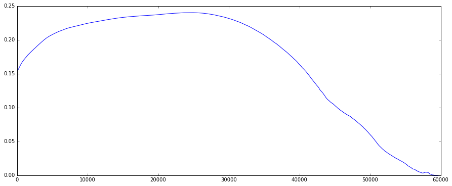

```python
X_pca_T2_sort=X_pca_T2.sort_values()
plt.plot(np.exp(X_pca_T2_scikit_kde.score_samples(X_pca_T2_sort.reshape(-1,1))))
```

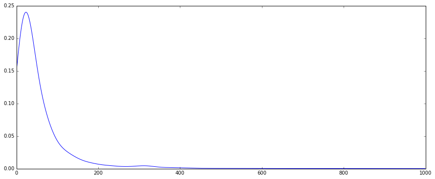

```python
X_pca_T2_dens_plot=np.linspace(0,50,1000)
plt.plot(np.exp(X_pca_T2_scikit_kde.score_samples(X_pca_T2_dens_plot.reshape(-1,1))))
```

```python
from scipy.integrate import quad
```

```python
def X_pca_T2_scikit_kde_func(x):
    return np.exp(X_pca_T2_scikit_kde.score_samples(x))

def X_pca_SPE_scikit_kde_func(x):
    return np.exp(X_pca_SPE_scikit_kde.score_samples(x))

def get_threshold_of_scikit_kde(kde,start,step=1,confidence=0.997):
    """get threshold by confidence"""
    i = start
    cumsum = quad(kde,-np.inf, start)[0]
    while True:
        if cumsum >= confidence:
            break
        cumsum = cumsum + quad(kde,i, i+step)[0]
        i = i + step

    return i

get_threshold_of_scikit_kde(X_pca_T2_scikit_kde_func,X_pca_T2.min())
```

```
77.000557321466047
```

##### option2:使用scipy 的KDE API估计概率密度

```python
from scipy import stats
```

```python
def my_kde_bandwidth(obj, fac=1./5):
    """We use Scott's Rule, multiplied by a constant factor."""
    return np.power(obj.n, -1./(obj.d+4)) * fac

X_pca_T2_scipy_kde=stats.gaussian_kde(X_pca_T2, bw_method=my_kde_bandwidth)
X_pca_SPE_scipy_kde=stats.gaussian_kde(X_pca_SPE, bw_method=my_kde_bandwidth)
```

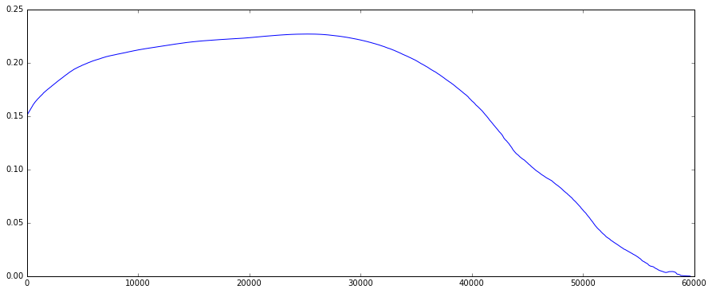

```python
plt.plot(X_pca_T2_scipy_kde.pdf(X_pca_T2_sort))
```

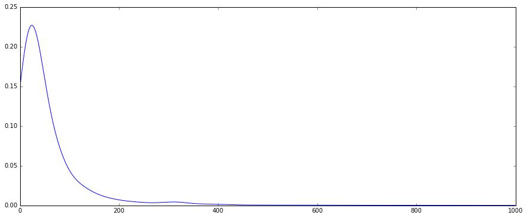

```python
plt.plot(X_pca_T2_scipy_kde.pdf(X_pca_T2_dens_plot))
```

```python
def get_threshold_of_scipy_kde(kde,start,step=1,confidence=0.997):
    """get threshold by confidence"""
    i = start
    cumsum = kde.integrate_box_1d(-np.inf, start)
    while True:
        if cumsum >= confidence:
            break
        cumsum = cumsum + kde.integrate_box_1d(i, i+step)
        i = i + step

    return i

get_threshold_of_scipy_kde(X_pca_T2_scipy_kde,X_pca_T2.min())
```

```
77.000557321466047
```

> 采用scikit-learn与scipy均可通过KDE进行阈值的确定，结果一致。但scipy无论是使用便捷性还是计算效率（ms级）都比scikit-learn（s级）要好，故后续使用scipy来进行计算。

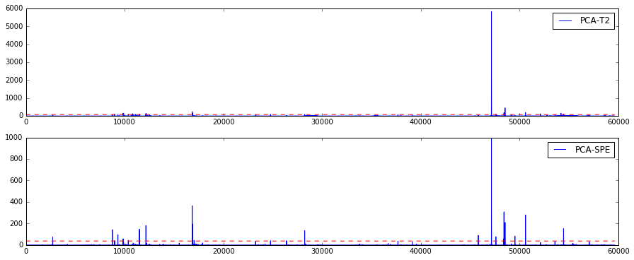

```python
plt.subplot(211)
plt.plot(X_pca_T2.values,label='PCA-T2')
plt.plot(get_threshold_of_scipy_kde(X_pca_T2_scipy_kde,X_pca_T2.min(),confidence=0.997)*np.ones(len(X_pca_T2)),'r--')
plt.legend(loc='best')

plt.subplot(212)
plt.plot(X_pca_SPE.values,label='PCA-SPE')
plt.plot(get_threshold_of_scipy_kde(X_pca_SPE_scipy_kde,X_pca_SPE.min(),confidence=0.997)*np.ones(len(X_pca_SPE)),'r--')
plt.legend(loc='best')
```

#### 3.1.3、检测到的异常时刻

##### T2检测

```python
X_pca_T2_anomaly=X_pca_T2[X_pca_T2>get_threshold_of_scipy_kde(X_pca_T2_scipy_kde,X_pca_T2.min(),confidence=0.997)].index
#10min聚合，注意第一个元素的处理
indice=pd.Series([True]+list(np.diff(X_pca_T2_anomaly)>10))
X_pca_T2_anomaly_plot=Series(np.ones(len(X_pca_T2_anomaly[indice])),index=X_pca_T2_anomaly[indice])
X_pca_T2_anomaly[indice]
```

```
PeriodIndex(['2016-10-07 02:23', '2016-10-07 05:43', '2016-10-07 20:00',
             '2016-10-08 04:44', '2016-10-08 11:42', '2016-10-08 12:49',
             '2016-10-08 16:18', '2016-10-08 23:34', '2016-10-09 09:55',
             '2016-10-09 10:32', '2016-10-12 16:45', '2016-10-12 17:00',
             '2016-10-12 17:13', '2016-10-17 03:45', '2016-10-18 04:56',
             '2016-10-20 14:40', '2016-10-27 04:06', '2016-11-02 18:29',
             '2016-11-03 02:07', '2016-11-03 15:38', '2016-11-03 17:34',
             '2016-11-05 04:06', '2016-11-06 05:19', '2016-11-07 05:51',
             '2016-11-07 15:58', '2016-11-07 20:17'],
            dtype='int64', name='vtime', freq='T')
```

##### SPE检测

```python
X_pca_SPE_anomaly=X_pca_SPE[X_pca_SPE>get_threshold_of_scipy_kde(X_pca_SPE_scipy_kde,X_pca_SPE.min(),confidence=0.997)].index
indice=pd.Series([True]+list(np.diff(X_pca_SPE_anomaly)>10))
X_pca_SPE_anomaly_plot=Series(np.ones(len(X_pca_SPE_anomaly[indice])),index=X_pca_SPE_anomaly[indice])
X_pca_SPE_anomaly[indice]
```

```
PeriodIndex(['2016-10-02 21:08', '2016-10-07 02:19', '2016-10-07 05:44',
             '2016-10-07 11:09', '2016-10-07 20:02', '2016-10-08 04:44',
             '2016-10-08 23:31', '2016-10-09 10:30', '2016-10-12 16:44',
             '2016-10-12 19:54', '2016-10-18 04:56', '2016-10-19 08:07',
             '2016-10-20 14:36', '2016-11-01 19:42', '2016-11-02 18:31',
             '2016-11-03 02:06', '2016-11-03 15:38', '2016-11-03 17:34',
             '2016-11-04 10:14', '2016-11-05 04:04', '2016-11-07 20:11'],
            dtype='int64', name='vtime', freq='T')
```

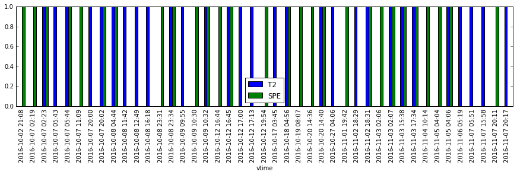

```python
anomaly_plot=pd.concat([X_pca_T2_anomaly_plot,X_pca_SPE_anomaly_plot],axis=1)
anomaly_plot.columns=['T2','SPE']

#以SPE为基准，10min聚合观察
for i in range(1,len(anomaly_plot)-1):
    if (anomaly_plot.index[i]-anomaly_plot.index[i-1])<=10:
        anomaly_plot.ix[i,:]=1

anomaly_plot.plot(kind='bar',figsize=(15, 3))
```

> 将SPE与T2同时检测到异常的时刻确定为异常时刻，考虑到采样和插值误差，可以将SPE 10min范围内出现的T2视为同时出现

### 3.2、ICA

```python
from sklearn.decomposition import FastICA
```

#### 3.2.1、确定独立成分个数

##### option1:使用混合矩阵能量占比确定独立成分

```python
def get_ica_components(X,contribution=components_percent):
    X_ica=FastICA(n_components=len(X.columns)).fit(X)

    L2=Series(np.sum(X_ica.mixing_**2,axis=0))
    L2.sort_values(ascending=False,inplace=True)

    X_S=DataFrame(X_ica.transform(X))
    X_ica_mixing_=DataFrame(X_ica.mixing_)

    L2.drop(L2.index[L2.cumsum()/L2.sum()>=contribution][1:],inplace=True)

    return X_S.reindex(columns=L2.index).values,X_ica_mixing_.reindex(columns=L2.index).values,X_ica.mean_,len(L2)
```

```python
X_S_,X_ica_mixing_,X_ica_mean_,n=get_ica_components(X)
print(X.shape,X_S_.shape,X_ica_mixing_.shape,n)
```

```
(59659, 6) (59659, 5) (6, 5) 5
```

##### option2:使用R2统计量确定独立成分个数

```python
def get_ica_n_components(X,r2_score_value=components_percent):
    for i in np.arange(len(X.columns)-1):
        X_ica=FastICA(n_components=len(X.columns)-i-1).fit(X)
        X_S=X_ica.transform(X)
        if r2_score(X, np.dot(X_S,X_ica.mixing_.T)+X_ica.mean_,multioutput='variance_weighted') < r2_score_value:
            break;
    return len(X.columns)-i

n=get_ica_n_components(X)
n
```

```
4
```

##### option3：使用PCA的主成分个数

```python
n=X_pca.n_components_
n
```

```
4
```

#### 3.2.2、ICA数据探索

```python
X_ica=FastICA(n_components=n).fit(X)
```

```python
X_S_=X_ica.transform(X)
```

```python
#各种算法的变量统一，便于后续计算
X_ica_mixing_=X_ica.mixing_
X_ica_mean_=X_ica.mean_
```

```python
print(X.shape,X_S_.shape,X_ica_mixing_.shape,X_ica.components_.shape)
```

```
(59659, 6) (59659, 4) (6, 4) (4, 6)
```

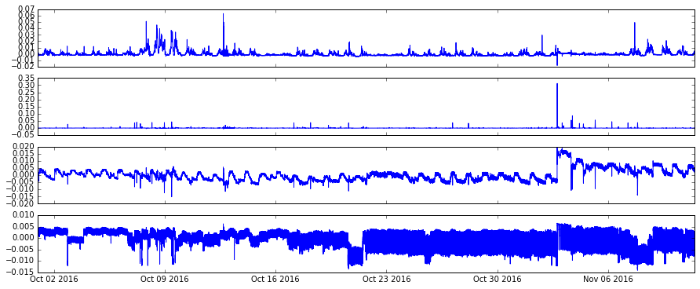

```python
#观察独立成分
fig,axes=plt.subplots(n,1,sharex=True)
xtick=X.index.to_datetime()
for i in range(n):
    axes[i].plot(xtick,X_S_[:,i])
```

> 从分解出的独立成分可以看出，大致与CPU、（DiskRead/DiskWrite）、MemUsage、（NwIngress/NwEgress）对应，这与ICA算法原理有关，因为ICA会先利用PCA进行白化预处理，使得原来所求的解混合矩阵退化成一个正交阵，自由度降为N*（N-1）/2，减少了ICA的工作量。而由于PCA本身具有降维功能，当观测信号的个数大于源信号个数时，白化也具有将观测信号数目降到与源信号维数相同的功效。

```python
X_ica_recover=DataFrame(np.dot(X_S_,X_ica_mixing_.T)+X_ica_mean_,index=X.index,columns=X.columns)
```

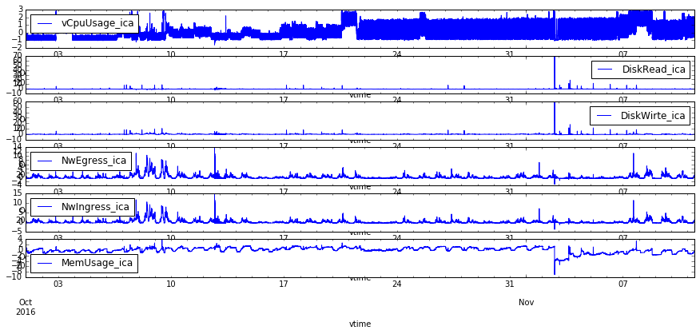

```python
plt.subplot(611)
X_ica_recover.vCpuUsage.plot(label='vCpuUsage_ica')
plt.legend(loc='best')
plt.subplot(612)
X_ica_recover.vDiskRead.plot(label='DiskRead_ica')
plt.legend(loc='best')
plt.subplot(613)
X_ica_recover.vDiskWrite.plot(label='DiskWirte_ica')
plt.legend(loc='best')
plt.subplot(614)
X_ica_recover.vNwEgress.plot(label='NwEgress_ica')
plt.legend(loc='best')
plt.subplot(615)
X_ica_recover.vNwIngress.plot(label='NwIngress_ica')
plt.legend(loc='best')
plt.subplot(616)
X_ica_recover.vMemUsage.plot(label='MemUsage_ica')
plt.legend(loc='best')
```

```python
r2_score(X,X_ica_recover,multioutput='variance_weighted')
```

```
0.90016013660614025
```

```python
#计算T2统计量
X_ica_T2=Series(np.sum(X_S_**2,axis=1),index=X.index)
```

```python
#计算SPE统计量
X_ica_SPE=Series(np.sum((X-X_ica_recover)**2,axis=1),index=X.index)
```

#### 3.2.3、采用置信度确定阈值

```python
X_ica_T2_scipy_kde=stats.gaussian_kde(X_ica_T2, bw_method=my_kde_bandwidth)
X_ica_SPE_scipy_kde=stats.gaussian_kde(X_ica_SPE, bw_method=my_kde_bandwidth)
```

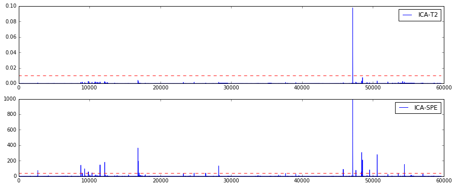

```python
plt.subplot(211)
plt.plot(X_ica_T2.values,label='ICA-T2')
plt.plot(get_threshold_of_scipy_kde(X_ica_T2_scipy_kde,X_ica_T2.min(),step=0.01,confidence=0.997)*np.ones(len(X_ica_T2)),'r--')
plt.legend(loc='best')

plt.subplot(212)
plt.plot(X_ica_SPE.values,label='ICA-SPE')
plt.plot(get_threshold_of_scipy_kde(X_ica_SPE_scipy_kde,X_ica_SPE.min(),confidence=0.997)*np.ones(len(X_ica_SPE)),'r--')
plt.legend(loc='best')
```

#### 3.2.4、检测到的异常时刻

##### T2检测

```python
X_ica_T2_anomaly=X_ica_T2[X_ica_T2>get_threshold_of_scipy_kde(X_ica_T2_scipy_kde,X_ica_T2.min(),step=0.01,confidence=0.997)].index
#10min聚合，注意第一个元素的处理
indice=pd.Series([True]+list(np.diff(X_ica_T2_anomaly)>10))
X_ica_T2_anomaly_plot=Series(np.ones(len(X_ica_T2_anomaly[indice])),index=X_ica_T2_anomaly[indice])
X_ica_T2_anomaly[indice]
```

```
PeriodIndex(['2016-11-02 18:31'], dtype='int64', name='vtime', freq='T')
```

##### SPE检测

```python
X_ica_SPE_anomaly=X_ica_SPE[X_ica_SPE>get_threshold_of_scipy_kde(X_ica_SPE_scipy_kde,X_ica_SPE.min(),confidence=0.997)].index
indice=pd.Series([True]+list(np.diff(X_ica_SPE_anomaly)>10))
X_ica_SPE_anomaly_plot=Series(np.ones(len(X_ica_SPE_anomaly[indice])),index=X_ica_SPE_anomaly[indice])
X_ica_SPE_anomaly[indice]
```

```
PeriodIndex(['2016-10-02 21:08', '2016-10-07 02:19', '2016-10-07 05:44',
             '2016-10-07 11:09', '2016-10-07 20:02', '2016-10-08 04:44',
             '2016-10-08 23:31', '2016-10-09 10:30', '2016-10-12 16:44',
             '2016-10-12 19:54', '2016-10-18 04:56', '2016-10-19 08:07',
             '2016-10-20 14:36', '2016-11-01 19:42', '2016-11-02 18:31',
             '2016-11-03 02:06', '2016-11-03 15:38', '2016-11-03 17:34',
             '2016-11-04 10:14', '2016-11-05 04:04', '2016-11-07 20:11'],
            dtype='int64', name='vtime', freq='T')
```

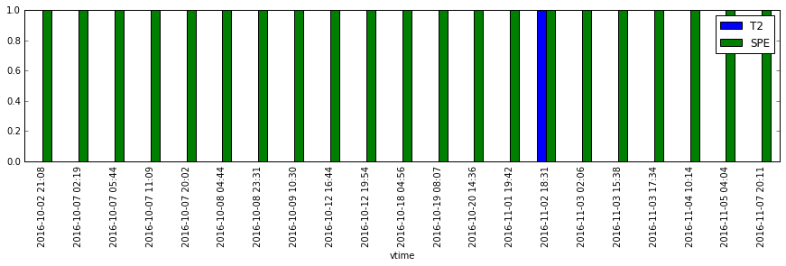

```python
anomaly_plot=pd.concat([X_ica_T2_anomaly_plot,X_ica_SPE_anomaly_plot],axis=1)
anomaly_plot.columns=['T2','SPE']

#以SPE为基准，10min聚合观察
for i in range(1,len(anomaly_plot)-1):
    if (anomaly_plot.index[i]-anomaly_plot.index[i-1])<=10:
        anomaly_plot.ix[i,:]=1

anomaly_plot.plot(kind='bar',figsize=(15, 3))
```

> ica检测效果明显优于pca，理论上应该是原始数据分布更趋向于非高斯，比较适合ica算法的假设

### 3.3、LLE

```python
from sklearn import manifold
```

#### 3.3.1、LLE数据探索

> 通过3D降维，观察图形的流行特征

```python
#降到3维观察
X_lle_embed=manifold.LocallyLinearEmbedding(n_neighbors =10, n_components=3).fit_transform(X)
```

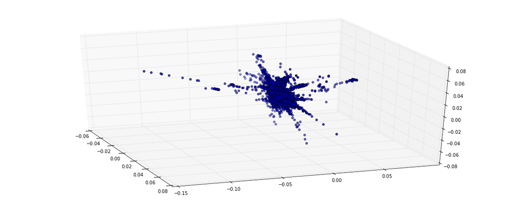

```python
from mpl_toolkits.mplot3d import Axes3D
fig = plt.figure()
ax = Axes3D(fig, elev=30, azim=-20)
ax.scatter(X_lle_embed[:,0], X_lle_embed[:,1], X_lle_embed[:,2], marker='o', cmap=plt.cm.rainbow)
```

> LLE具有不受数据分布约束的优势，能够较好的保留数据的局部结构，可降维到3D图形观察数据特征。图示并不具有典型的流行结构，因此采用流行算法的必要性不高。而且由于LLE的k，d参数目前没有较好的手段确定，且算法本身计算复杂度也比较高，因此不推荐使用。这里出于研究目的，仍给出LLE的算法参考。

#### 3.3.2、LLE数据处理

```python
X_lle_embed=manifold.LocallyLinearEmbedding(n_neighbors =10, n_components=5).fit_transform(X)
```

```python
X_lle_embed_mean=X_lle_embed.mean(axis=0)
X_lle_embed_mean
```

```
array([-0.00039877,  0.00236896, -0.00086952,  0.00072364, -0.00198834])
```

```python
X_lle_vi=nlg.inv(np.cov(X_lle_embed.T))
X_lle_vi
```

```
array([[  61305.59651835,   -9787.9328303 ,    3592.61369351,
          -2989.87574858,    8215.30561272],
       [  -9787.9328303 ,  117805.5063972 ,  -21342.76270056,
          17762.05683385,  -48804.94624892],
       [   3592.61369351,  -21342.76270056,   67491.75845184,
          -6519.47757638,   17913.62090902],
       [  -2989.87574858,   17762.05683385,   -6519.47757638,
          65083.69548578,  -14908.2270721 ],
       [   8215.30561272,  -48804.94624892,   17913.62090902,
         -14908.2270721 ,  100621.45528713]])
```

```python
#计算的是到均值的马氏距离
X_lle_T2=Series([np.dot(np.dot(X_lle_embed[i]-X_lle_embed_mean,X_lle_vi),X_lle_embed[i]-X_lle_embed_mean)
                 for i in np.arange(len(X_lle_embed))],index=X.index)
```

```python
X_lle_T2.describe()
```

```
count    59659.000000
mean         4.999916
std         29.702727
min          0.000293
25%          0.091677
50%          0.284838
75%          1.071523
max       1400.344024
dtype: float64
```

```python
X_lle_T2_scipy_kde=stats.gaussian_kde(X_lle_T2, bw_method=my_kde_bandwidth)
```

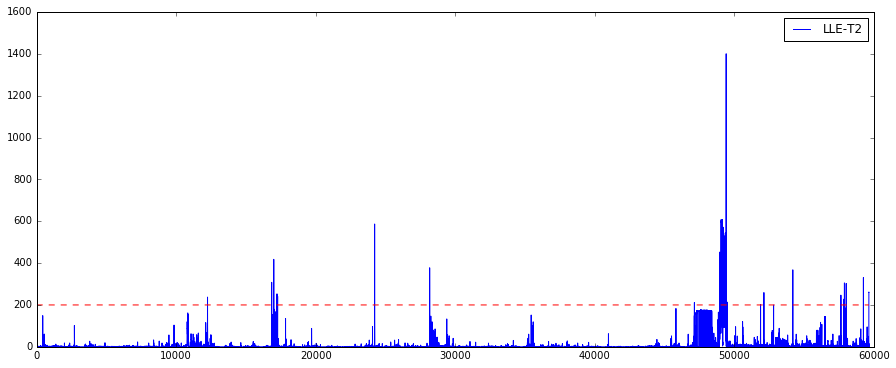

```python
plt.plot(X_lle_T2.values,label='LLE-T2')
plt.plot(get_threshold_of_scipy_kde(X_lle_T2_scipy_kde,X_lle_T2.min(),confidence=0.997)*np.ones(len(X_lle_T2)),'r--')
plt.legend(loc='best')
```

#### 3.3.3、检测到的异常时刻

```python
X_lle_T2_anomaly=X_lle_T2[X_lle_T2>get_threshold_of_scipy_kde(X_lle_T2_scipy_kde,X_lle_T2.min(),confidence=0.997)].index
#10min聚合，注意第一个元素的处理
indice=pd.Series([True]+list(np.diff(X_lle_T2_anomaly)>10))
X_lle_T2_anomaly[indice]
```

```
PeriodIndex(['2016-10-09 12:04', '2016-10-12 16:45', '2016-10-12 19:15',
             '2016-10-12 23:07', '2016-10-12 23:52', '2016-10-17 19:44',
             '2016-10-20 13:31', '2016-11-02 18:28', '2016-11-04 00:43',
             '2016-11-04 01:16', '2016-11-04 01:50', '2016-11-04 02:12',
             '2016-11-04 02:46', '2016-11-04 03:19', '2016-11-04 03:53',
             '2016-11-04 04:59', '2016-11-04 05:33', '2016-11-04 06:06',
             '2016-11-04 06:39', '2016-11-04 07:23', '2016-11-04 07:45',
             '2016-11-04 08:18', '2016-11-04 09:32', '2016-11-06 01:29',
             '2016-11-06 05:29', '2016-11-07 15:59', '2016-11-10 01:28',
             '2016-11-10 04:31', '2016-11-10 05:38', '2016-11-10 07:45',
             '2016-11-11 04:21', '2016-11-11 10:52'],
            dtype='int64', name='vtime', freq='T')
```

> T2误检时刻较多。由于LLE算法是非线性算法，无法转换到原始数据空间，因此不能计算SPE。

### 3.4、不降维，直接采用马氏距离平方进行度量

> 由于特征较少，出于研究目的，本小节给出不降维的异常检测结果用于对比

```python
from scipy import spatial
```

```python
#计算每个样本到均值的马氏距离
X_vi=nlg.inv(np.cov(X.T))
X_mahalanobis_dist=[spatial.distance.pdist(np.array([X.ix[i],X_mean]),metric='mahalanobis',VI=X_vi)[0] for i in np.arange(len(X))]
```

```python
X_mahalanobis_dist2=Series(np.square(X_mahalanobis_dist),index=X.index)
```

```python
X_mahalanobis_dist2_scipy_kde=stats.gaussian_kde(X_mahalanobis_dist2, bw_method=my_kde_bandwidth)
```

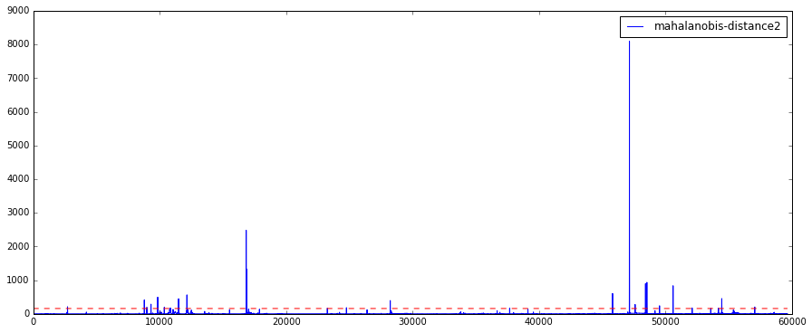

```python
plt.plot(X_mahalanobis_dist2.values,label='mahalanobis-distance2')
plt.plot(get_threshold_of_scipy_kde(X_mahalanobis_dist2_scipy_kde,X_mahalanobis_dist2.min(),confidence=0.997)
         *np.ones(len(X_mahalanobis_dist2)),'r--')
plt.legend(loc='best')
```

#### 检测到的异常时刻

```python
X_mahalanobis_dist2_anomaly=X_mahalanobis_dist2[X_mahalanobis_dist2>get_threshold_of_scipy_kde(X_mahalanobis_dist2_scipy_kde,X_mahalanobis_dist2.min(),confidence=0.997)].index
#10min聚合，注意第一个元素的处理
indice=pd.Series([True]+list(np.diff(X_mahalanobis_dist2_anomaly)>10))
X_mahalanobis_dist2_anomaly[indice]
```

```
PeriodIndex(['2016-10-02 21:10', '2016-10-07 02:20', '2016-10-07 05:44',
             '2016-10-07 11:11', '2016-10-07 20:00', '2016-10-08 04:44',
             '2016-10-08 12:04', '2016-10-08 13:14', '2016-10-08 23:31',
             '2016-10-09 10:31', '2016-10-12 16:44', '2016-10-17 03:45',
             '2016-10-18 04:56', '2016-10-20 14:37', '2016-10-27 04:06',
             '2016-11-01 19:40', '2016-11-02 18:30', '2016-11-03 02:06',
             '2016-11-03 15:37', '2016-11-03 17:34', '2016-11-04 10:16',
             '2016-11-05 04:05', '2016-11-06 05:20', '2016-11-07 05:51',
             '2016-11-07 16:01', '2016-11-07 20:12', '2016-11-09 15:49'],
            dtype='int64', name='vtime', freq='T')
```

## 4、相关性变化分析

> 某些故障发生时会出现过程变量均值、方差不变而过程变量间相关性发生改变的情况，对此操作维护人员凭肉眼是无法察觉到的。相关性变化分析是通过分析每个变量之间的相关性变化来进行故障检测。首先采用移动窗的方法对数据进行处理，形成的相关性矩阵中需要去除自相关的部分，然后再对这个数据矩阵进行处理。

### 4.1、形成待分析的相关性矩阵

```python
# DataFrame X(n*m),n:sample;m:dimention
def get_multiindex(X):
    dim=int(X.shape[1]*(X.shape[1]-1)/2)
    multiindex=[0]*dim
    count=0
    for j in range(X.shape[1]):
        for k in range(j+1,X.shape[1]):
            multiindex[count]=(X.columns[j],X.columns[k])
            count=count+1
    return multiindex

#默认窗口win个点，每次移动的步长是step，重叠部分为win-step
def get_X_cov_values_by_win(X,win,step):
    irow=int(X.shape[0]/step)
    if X.shape[0]-irow*step>0:
        irow=irow+1
    icolumn=int(X.shape[1]*(X.shape[1]-1)/2)
    X_cov_values = np.empty([irow, icolumn])

    for i in range(irow):
        istep=i*step
        X_win=X[istep:istep+win] if (istep+win)<X.shape[0] else X[i:]

        X_win_cov=np.cov(X_win.T)
        count=0
        for j in range(len(X_win_cov)):
            for k in range(j+1,len(X_win_cov)):
                X_cov_values[i,count]=X_win_cov[j,k]
                count=count+1

    return X_cov_values
```

```python
win=100
step=60
X_win_cov_values = get_X_cov_values_by_win(X,win,step)
X_win_cov_multiindex_1,X_win_cov_multiindex_2=zip(*get_multiindex(X))
X_win_cov=DataFrame(X_win_cov_values,index=X.index[::step],columns=[list(X_win_cov_multiindex_1),list(X_win_cov_multiindex_2)])
X_win_cov.head()
```

| vtime | vCpuUsage vDiskRead | vCpuUsage vDiskWrite | vCpuUsage vNwEgress | vCpuUsage vNwIngress | vCpuUsage vMemUsage | vDiskRead vDiskWrite | vDiskRead vNwEgress | vDiskRead vNwIngress | vDiskRead vMemUsage | vDiskWrite vNwEgress | vDiskWrite vNwIngress | vDiskWrite vMemUsage | vNwEgress vNwIngress | vNwEgress vMemUsage | vNwIngress vMemUsage |
| --- | --- | --- | --- | --- | --- | --- | --- | --- | --- | --- | --- | --- | --- | --- | --- |
| 2016-10-01 00:00 | 4.480824e-04 | -0.003431 | 0.000880 | 0.000605 | -0.001725 | 2.051915e-03 | 2.594193e-03 | 1.123874e-03 | 2.017996e-03 | 0.038585 | 0.036646 | -0.012574 | 0.054454 | 0.031628 | 0.024092 |
| 2016-10-01 01:00 | 1.560159e-04 | -0.004658 | 0.003128 | 0.001776 | -0.000276 | 1.381172e-03 | 5.318453e-03 | 3.468881e-03 | 1.290691e-02 | 0.009457 | 0.005994 | 0.017511 | 0.027482 | 0.118254 | 0.086499 |
| 2016-10-01 02:00 | 7.159012e-34 | -0.003111 | -0.001934 | -0.002269 | 0.006425 | 2.188557e-34 | -1.361769e-34 | 1.167230e-35 | -2.256645e-34 | 0.009655 | 0.006080 | 0.011018 | 0.008349 | 0.016095 | 0.008696 |
| 2016-10-01 03:00 | -6.925566e-34 | -0.001804 | -0.001692 | -0.001254 | -0.002197 | -7.781535e-35 | 2.801353e-34 | -3.890768e-34 | 9.882550e-34 | 0.011702 | 0.007792 | 0.017497 | 0.010106 | 0.018504 | 0.012836 |
| 2016-10-01 04:00 | 4.707829e-34 | -0.000061 | 0.000226 | 0.000066 | 0.001938 | -1.264499e-34 | -3.307152e-34 | -5.408167e-34 | 7.781535e-35 | 0.002615 | 0.001095 | 0.006125 | 0.001126 | 0.005995 | 0.002524 |

### 4.2、PCA

```
anomal periods detected by T2 metric are:
(Period('2016-11-02 17:40', 'T'), Period('2016-11-02 19:20', 'T'))
(Period('2016-11-02 18:40', 'T'), Period('2016-11-02 20:20', 'T'))
(Period('2016-11-03 16:40', 'T'), Period('2016-11-03 18:20', 'T'))
anomal periods detected by SPE metric are:
(Period('2016-10-08 15:00', 'T'), Period('2016-10-08 16:40', 'T'))
(Period('2016-11-02 18:40', 'T'), Period('2016-11-02 20:20', 'T'))
(Period('2016-11-07 14:40', 'T'), Period('2016-11-07 16:20', 'T'))
```

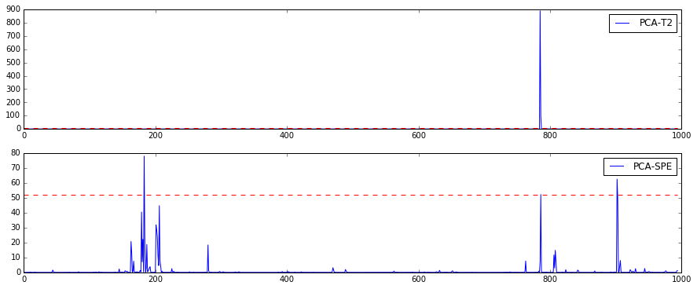

```python
X_win_cov_pca=PCA(n_components=0.85).fit(X_win_cov)
X_win_cov_pca_recover=DataFrame(np.dot(X_win_cov,np.dot(X_win_cov_pca.components_.T,X_win_cov_pca.components_)),
                                index=X_win_cov.index,columns=X_win_cov.columns)

#计算T2统计量
X_win_cov_pca_T2=Series([np.dot(np.dot(np.dot(np.dot(X_win_cov.ix[i].T,X_win_cov_pca.components_.T),
                                              nlg.inv(np.diag(X_win_cov_pca.explained_variance_))),X_win_cov_pca.components_),X_win_cov.ix[i])
                         for i in np.arange(len(X_win_cov))],index=X_win_cov.index)
#计算SPE统计量
X_win_cov_pca_SPE=Series(np.sum((X_win_cov-X_win_cov_pca_recover)**2,axis=1),index=X_win_cov.index)

#kde及阈值估计
X_win_cov_pca_T2_scipy_kde=stats.gaussian_kde(X_win_cov_pca_T2, bw_method=my_kde_bandwidth)
X_win_cov_pca_SPE_scipy_kde=stats.gaussian_kde(X_win_cov_pca_SPE, bw_method=my_kde_bandwidth)
X_win_cov_pca_T2_threshold=get_threshold_of_scipy_kde(X_win_cov_pca_T2_scipy_kde,X_win_cov_pca_T2.min(),confidence=0.997)
X_win_cov_pca_SPE_threshold=get_threshold_of_scipy_kde(X_win_cov_pca_SPE_scipy_kde,X_win_cov_pca_SPE.min(),confidence=0.997)

#绘图
plt.subplot(211)
plt.plot(X_win_cov_pca_T2.values,label='PCA-T2')
plt.plot(X_win_cov_pca_T2_threshold*np.ones(len(X_win_cov_pca_T2)),'r--')
plt.legend(loc='best')
plt.subplot(212)
plt.plot(X_win_cov_pca_SPE.values,label='PCA-SPE')
plt.plot(X_win_cov_pca_SPE_threshold*np.ones(len(X_win_cov_pca_SPE)),'r--')
plt.legend(loc='best')

#输出异常时间段
X_win_cov_pca_T2_anomaly=X_win_cov_pca_T2[X_win_cov_pca_T2>X_win_cov_pca_T2_threshold].index
print('anomal periods detected by T2 metric are: ')
for each in zip(X_win_cov_pca_T2_anomaly,X_win_cov_pca_T2_anomaly+win):
    print(each)
print('anomal periods detected by SPE metric are: ')
X_win_cov_pca_SPE_anomaly=X_win_cov_pca_SPE[X_win_cov_pca_SPE>X_win_cov_pca_SPE_threshold].index
for each in zip(X_win_cov_pca_SPE_anomaly,X_win_cov_pca_SPE_anomaly+win):
    print(each)
```

### 4.3、ICA

```
anomal periods detected by T2 metric are:
(Period('2016-11-02 17:40', 'T'), Period('2016-11-02 19:20', 'T'))
(Period('2016-11-02 18:40', 'T'), Period('2016-11-02 20:20', 'T'))
anomal periods detected by SPE metric are:
(Period('2016-10-09 11:00', 'T'), Period('2016-10-09 12:40', 'T'))
(Period('2016-11-03 14:40', 'T'), Period('2016-11-03 16:20', 'T'))
```

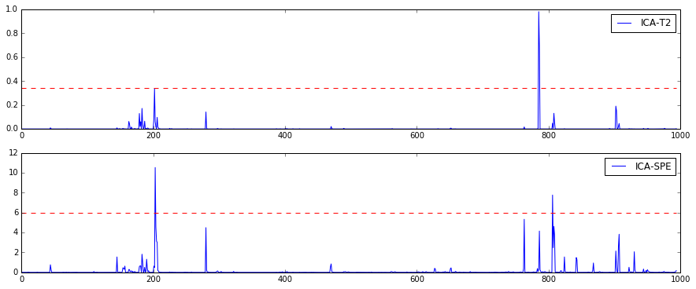

```python
n=X_pca.n_components_
X_win_cov_ica=FastICA(n_components=n).fit(X_win_cov)
X_win_cov_S_=X_win_cov_ica.transform(X_win_cov)
X_win_cov_ica_recover=DataFrame(np.dot(X_win_cov_S_,X_win_cov_ica.mixing_.T)+X_win_cov_ica.mean_,
                                index=X_win_cov.index,columns=X_win_cov.columns)

#计算T2统计量
X_win_cov_ica_T2=Series(np.sum(X_win_cov_S_**2,axis=1),index=X_win_cov.index)
#计算SPE统计量
X_win_cov_ica_SPE=Series(np.sum((X_win_cov-X_win_cov_ica_recover)**2,axis=1),index=X_win_cov.index)

#kde及阈值估计
X_win_cov_ica_T2_scipy_kde=stats.gaussian_kde(X_win_cov_ica_T2, bw_method=my_kde_bandwidth)
X_win_cov_ica_SPE_scipy_kde=stats.gaussian_kde(X_win_cov_ica_SPE, bw_method=my_kde_bandwidth)
X_win_cov_ica_T2_threshold=get_threshold_of_scipy_kde(X_win_cov_ica_T2_scipy_kde,X_win_cov_ica_T2.min(),step=0.01,confidence=0.997)
X_win_cov_ica_SPE_threshold=get_threshold_of_scipy_kde(X_win_cov_ica_SPE_scipy_kde,X_win_cov_ica_SPE.min(),confidence=0.997)

#绘图
plt.subplot(211)
plt.plot(X_win_cov_ica_T2.values,label='ICA-T2')
plt.plot(X_win_cov_ica_T2_threshold*np.ones(len(X_win_cov_ica_T2)),'r--')
plt.legend(loc='best')
plt.subplot(212)
plt.plot(X_win_cov_ica_SPE.values,label='ICA-SPE')
plt.plot(X_win_cov_ica_SPE_threshold*np.ones(len(X_win_cov_ica_SPE)),'r--')
plt.legend(loc='best')

#输出异常时间段
X_win_cov_ica_T2_anomaly=X_win_cov_ica_T2[X_win_cov_ica_T2>X_win_cov_ica_T2_threshold].index
print('anomal periods detected by T2 metric are: ')
for each in zip(X_win_cov_ica_T2_anomaly,X_win_cov_ica_T2_anomaly+win):
    print(each)
print('anomal periods detected by SPE metric are: ')
X_win_cov_ica_SPE_anomaly=X_win_cov_ica_SPE[X_win_cov_ica_SPE>X_win_cov_ica_SPE_threshold].index
for each in zip(X_win_cov_ica_SPE_anomaly,X_win_cov_ica_SPE_anomaly+win):
    print(each)
```

> 直观理解：T2度量的是能量较大的主元空间，SPE度量的是以噪声为主的能量较小的残差空间，因此当度量相同的数据变化程度时，SPE对T2而言，会更敏感；

### 4.4、LLE

```
anomal periods detected by T2 metric are:
(Period('2016-10-08 15:00', 'T'), Period('2016-10-08 16:40', 'T'))
(Period('2016-10-09 10:00', 'T'), Period('2016-10-09 11:40', 'T'))
(Period('2016-11-04 09:40', 'T'), Period('2016-11-04 11:20', 'T'))
```

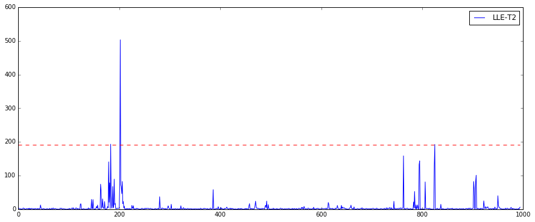

```python
X_win_cov_lle_embed=manifold.LocallyLinearEmbedding(n_neighbors =10, n_components=5).fit_transform(X_win_cov)
X_win_cov_lle_embed_mean=X_win_cov_lle_embed.mean(axis=0)
X_win_cov_lle_vi=nlg.inv(np.cov(X_win_cov_lle_embed.T))

#计算的是到均值的马氏距离
X_win_cov_lle_T2=Series([np.dot(np.dot(X_win_cov_lle_embed[i]-X_win_cov_lle_embed_mean,X_win_cov_lle_vi),
                                X_win_cov_lle_embed[i]-X_win_cov_lle_embed_mean)
                 for i in np.arange(len(X_win_cov_lle_embed))],index=X_win_cov.index)

#kde及阈值估计
X_win_cov_lle_T2_scipy_kde=stats.gaussian_kde(X_win_cov_lle_T2, bw_method=my_kde_bandwidth)
X_win_cov_lle_T2_threshold=get_threshold_of_scipy_kde(X_win_cov_lle_T2_scipy_kde,X_win_cov_lle_T2.min(),confidence=0.997)

#绘图
plt.plot(X_win_cov_lle_T2.values,label='LLE-T2')
plt.plot(X_win_cov_lle_T2_threshold*np.ones(len(X_win_cov_lle_T2)),'r--')
plt.legend(loc='best')

#输出异常时间段
X_win_cov_lle_T2_anomaly=X_win_cov_lle_T2[X_win_cov_lle_T2>X_win_cov_lle_T2_threshold].index
print('anomal periods detected by T2 metric are: ')
for each in zip(X_win_cov_lle_T2_anomaly,X_win_cov_lle_T2_anomaly+win):
    print(each)
```